# Project: Medical Appointment No Shows

- Introduction
- Data Wrangling
- Exploratory Data Analysis
  - Does number of days between the scheduled day and appointment have an effect on if the patient will show up or not?
  - Which features are related to whether the patient will show up or not?
  - Which age groups are more likely to show up or not?
  - Which appointment day of the week are patients more likely to show up or not?
  - Are patients that received an SMS more likely to show up?
- Conclusions

## Introduction

> A person makes a doctor appointment, receives all the instructions and no-show. Who to blame?  
> Here, we will analyze and explore a [dataset](https://www.kaggle.com/joniarroba/noshowappointments) that contains 100k medical appointments in Brazil, where a number of characteristics about the patient are included in each row.  
> And after that, come up with possible conclusions as to why so many patients do not show up to their appointment.

```python
# Import packages
import numpy as np
import pandas as pd
import matplotlib.pyplot as plt
import seaborn as sns
%matplotlib inline
```

## Data Wrangling

### General Properties

```python
# Load dataset
df = pd.read_csv('noshowappointments-kagglev2-may-2016.csv')
```

```python
# Create bar graph function with 2 variables
"""
    Creates a bar graph with two bars, to visually compare two values
    Args:
        (str) label1 - Label of the first bar (x coordinates)
        (str) label2 - Label of the second bar (x coordinates)
        (int or float) height1 - Height of the first bar
        (int or float) height2 - Height of the second bar
        (str) color1 - Color/hex code of the first bar, default is blue
        (str) color2 - Color/hex code of the first bar, default is red
        (str) title - Title of the graph, default is 'Title'
        (str) xlabel - X label of the graph, default is 'xlabel'
        (str) ylabel - Y label of the graph, default is 'ylabel'
    Returns:
        Bar graph with two bars
    """
def bargraph(label1, label2, height1, height2, color1='b', color2='r', title='Title', xlabel='xlabel', ylabel='ylabel'):
    sns.set()
    fig = plt.figure(figsize =(7, 4))
    plt.bar(label1, height1, label=label1, color=color1)
    plt.bar(label2, height2, label=label2, color=color2)
    plt.ylabel(ylabel)
    plt.xlabel(xlabel)
    plt.title(title)
    plt.legend()
    plt.show()
```

```python
df.head(3)
```

|  | PatientId | AppointmentID | Gender | ScheduledDay | AppointmentDay | Age | Neighbourhood | Scholarship | Hipertension | Diabetes | Alcoholism | Handcap | SMS_received | No-show |
| --- | --- | --- | --- | --- | --- | --- | --- | --- | --- | --- | --- | --- | --- | --- |
| 0 | 2.987250e+13 | 5642903 | F | 2016-04-29T18:38:08Z | 2016-04-29T00:00:00Z | 62 | JARDIM DA PENHA | 0 | 1 | 0 | 0 | 0 | 0 | No |
| 1 | 5.589978e+14 | 5642503 | M | 2016-04-29T16:08:27Z | 2016-04-29T00:00:00Z | 56 | JARDIM DA PENHA | 0 | 0 | 0 | 0 | 0 | 0 | No |
| 2 | 4.262962e+12 | 5642549 | F | 2016-04-29T16:19:04Z | 2016-04-29T00:00:00Z | 62 | MATA DA PRAIA | 0 | 0 | 0 | 0 | 0 | 0 | No |

```python
print('There are {} patients and {} columns'.format(df.shape[0], df.shape[1]))
```

```
There are 110527 patients and 14 columns
```

```python
df.info()
```

```
<class 'pandas.core.frame.DataFrame'>
RangeIndex: 110527 entries, 0 to 110526
Data columns (total 14 columns):
 #   Column          Non-Null Count   Dtype
---  ------          --------------   -----
 0   PatientId       110527 non-null  float64
 1   AppointmentID   110527 non-null  int64
 2   Gender          110527 non-null  object
 3   ScheduledDay    110527 non-null  object
 4   AppointmentDay  110527 non-null  object
 5   Age             110527 non-null  int64
 6   Neighbourhood   110527 non-null  object
 7   Scholarship     110527 non-null  int64
 8   Hipertension    110527 non-null  int64
 9   Diabetes        110527 non-null  int64
 10  Alcoholism      110527 non-null  int64
 11  Handcap         110527 non-null  int64
 12  SMS_received    110527 non-null  int64
 13  No-show         110527 non-null  object
dtypes: float64(1), int64(8), object(5)
memory usage: 11.8+ MB
```

- **ScheduledDay** and **AppointmentDay** need to be converted to datetime format
- Convert **Neighbourhood** from all caps to title

```python
df.describe()
```

|  | PatientId | AppointmentID | Age | Scholarship | Hipertension | Diabetes | Alcoholism | Handcap | SMS_received |
| --- | --- | --- | --- | --- | --- | --- | --- | --- | --- |
| count | 1.105270e+05 | 1.105270e+05 | 110527.000000 | 110527.000000 | 110527.000000 | 110527.000000 | 110527.000000 | 110527.000000 | 110527.000000 |
| mean | 1.474963e+14 | 5.675305e+06 | 37.088874 | 0.098266 | 0.197246 | 0.071865 | 0.030400 | 0.022248 | 0.321026 |
| std | 2.560949e+14 | 7.129575e+04 | 23.110205 | 0.297675 | 0.397921 | 0.258265 | 0.171686 | 0.161543 | 0.466873 |
| min | 3.921784e+04 | 5.030230e+06 | -1.000000 | 0.000000 | 0.000000 | 0.000000 | 0.000000 | 0.000000 | 0.000000 |
| 25% | 4.172614e+12 | 5.640286e+06 | 18.000000 | 0.000000 | 0.000000 | 0.000000 | 0.000000 | 0.000000 | 0.000000 |
| 50% | 3.173184e+13 | 5.680573e+06 | 37.000000 | 0.000000 | 0.000000 | 0.000000 | 0.000000 | 0.000000 | 0.000000 |
| 75% | 9.439172e+13 | 5.725524e+06 | 55.000000 | 0.000000 | 0.000000 | 0.000000 | 0.000000 | 0.000000 | 1.000000 |
| max | 9.999816e+14 | 5.790484e+06 | 115.000000 | 1.000000 | 1.000000 | 1.000000 | 1.000000 | 4.000000 | 1.000000 |

- 50% of the patients are aged 37 and below
- A huge majority of the patients don't have hipertension, diabetes, alcoholism or are handicapped
- Most patients did not recieve an SMS
- A huge majority of the patients do not have a scholarship

```python
df.nunique()
```

```
PatientId          62299
AppointmentID     110527
Gender                 2
ScheduledDay      103549
AppointmentDay        27
Age                  104
Neighbourhood         81
Scholarship            2
Hipertension           2
Diabetes               2
Alcoholism             2
Handcap                5
SMS_received           2
No-show                2
dtype: int64
```

- There are patients who made several appointments

```python
df['Age'].value_counts()
```

```
 0      3539
 1      2273
 52     1746
 49     1652
 53     1651
        ...
 115       5
 100       4
 102       2
 99        1
-1         1
Name: Age, Length: 104, dtype: int64
```

- There is a negative value for **Age** that should be removed

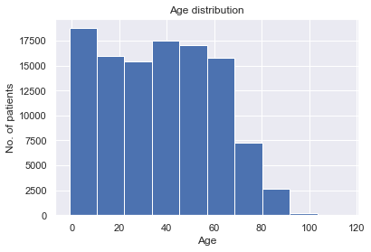

```python
sns.set()
plt.hist(df['Age'])
plt.title('Age distribution')
plt.xlabel('Age')
plt.ylabel('No. of patients')
plt.show()
```

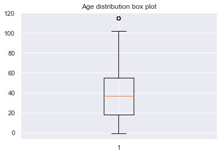

```python
sns.set()
plt.boxplot(df['Age'])
plt.title('Age distribution box plot')
plt.show()
```

```python
df['Gender'].value_counts()
```

```
F    71840
M    38687
Name: Gender, dtype: int64
```

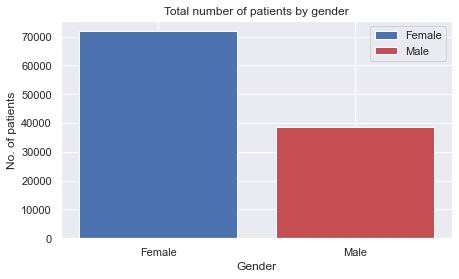

```python
bargraph('Female', 'Male', df['Gender'].value_counts().values[0], df['Gender'].value_counts().values[1],
         title='Total number of patients by gender',
         xlabel='Gender', ylabel='No. of patients')
```

- There are *71,840* female patients and *38,687* male patients
- There are more female patients than male patients
- 65% are female
- 35% are male

```python
df['Scholarship'].value_counts()
```

```
0    99666
1    10861
Name: Scholarship, dtype: int64
```

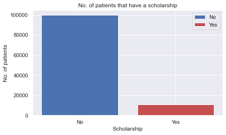

```python
bargraph('No', 'Yes', df['Scholarship'].value_counts().values[0], df['Scholarship'].value_counts().values[1],
         title='No. of patients that have a scholarship',
         xlabel='Scholarship', ylabel='No. of patients')
```

- 90% of the patients do not have a scholarship
- 10% of the patients have a scholarship

```python
df['Hipertension'].value_counts()
```

```
0    88726
1    21801
Name: Hipertension, dtype: int64
```

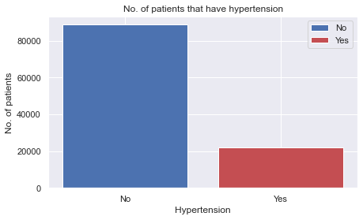

```python
bargraph('No', 'Yes', df['Hipertension'].value_counts().values[0], df['Hipertension'].value_counts().values[1],
         title='No. of patients that have hypertension',
         xlabel='Hypertension', ylabel='No. of patients')
```

- 80% of the patients do not have hypertension
- 20% of the patients have hypertension

```python
df['Diabetes'].value_counts()
```

```
0    102584
1      7943
Name: Diabetes, dtype: int64
```

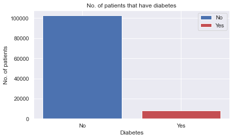

```python
bargraph('No', 'Yes', df['Diabetes'].value_counts().values[0], df['Diabetes'].value_counts().values[1],
         title='No. of patients that have diabetes',
         xlabel='Diabetes', ylabel='No. of patients')
```

- 93% of the patients do not have diabetes
- 7% of the patients have diabetes

```python
df['Alcoholism'].value_counts()
```

```
0    107167
1      3360
Name: Alcoholism, dtype: int64
```

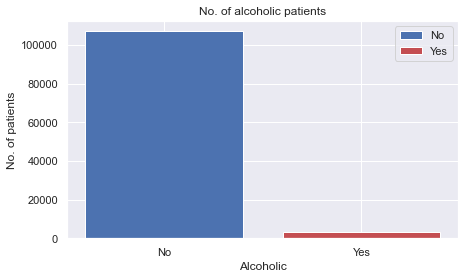

```python
bargraph('No', 'Yes', df['Alcoholism'].value_counts().values[0], df['Alcoholism'].value_counts().values[1],
         title='No. of alcoholic patients',
         xlabel='Alcoholic', ylabel='No. of patients')
```

- 97% of the patients are not alcoholics
- 3% of the patients are alcoholics

```python
df['Handcap'].value_counts()
```

```
0    108286
1      2042
2       183
3        13
4         3
Name: Handcap, dtype: int64
```

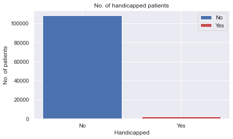

```python
bargraph('No', 'Yes', df['Handcap'].value_counts().values[0], df['Handcap'].value_counts().values[1],
         title='No. of handicapped patients',
         xlabel='Handicapped', ylabel='No. of patients')
```

- 98% of the patients are not handicapped
- 2% of the patients are handicapped
- **Handcap** has values (2, 3, 4) when it should only be 0 or 1

```python
df['SMS_received'].value_counts()
```

```
0    75045
1    35482
Name: SMS_received, dtype: int64
```

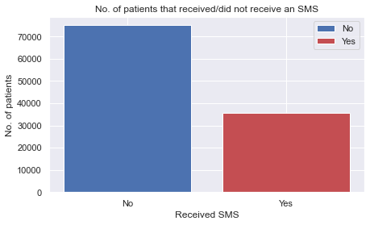

```python
bargraph('No', 'Yes', df['SMS_received'].value_counts().values[0], df['SMS_received'].value_counts().values[1],
         title='No. of patients that received/did not receive an SMS',
         xlabel='Received SMS', ylabel='No. of patients')
```

- 68% of the patients did not recieve an SMS
- 32% of the patients recieved an SMS
- **A huge majority of patients did NOT receive an SMS**

```python
df['No-show'].value_counts()
```

```
No     88208
Yes    22319
Name: No-show, dtype: int64
```

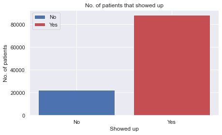

```python
bargraph('No', 'Yes', df['No-show'].value_counts().values[1], df['No-show'].value_counts().values[0],
         title='No. of patients that showed up',
         xlabel='Showed up', ylabel='No. of patients')
```

- 80% of the patients showed up
- 20% of the patients did not show up

```python
df['ScheduledDay'].value_counts()[0:3]
```

```
2016-05-06T07:09:54Z    24
2016-05-06T07:09:53Z    23
2016-04-25T17:17:46Z    22
Name: ScheduledDay, dtype: int64
```

```python
df['AppointmentDay'].value_counts()[0:3]
```

```
2016-06-06T00:00:00Z    4692
2016-05-16T00:00:00Z    4613
2016-05-09T00:00:00Z    4520
Name: AppointmentDay, dtype: int64
```

- No time specified for `AppointmentDay` (all 00:00:00)
- Both `AppointmentDay` and `ScheduledDay` are not in datetime format

### Data Dictionary

- **01 - PatientId:** Identification of a patient
- **02 - AppointmentID:** Identification of each appointment
- **03 - Gender:** Male or Female. Female is the greater proportion, woman takes way more care of they health in comparison to man.
- **04 - ScheduledDay:** The day someone called or registered the appointment, this is before appointment of course.
- **05 - AppointmentDay:** The day of the actual appointment, when they have to visit the doctor.
- **06 - Age:** How old the patient is.
- **07 - Neighbourhood:** Where the appointment takes place.
- **08 - Scholarship:** True of False.  
  Indicates whether or not the patient is enrolled in Brasilian welfare program [Bolsa Família.](https://en.wikipedia.org/wiki/Bolsa_Fam%C3%ADlia)
- **09 - Hipertension:** True or False  
  If the patient has hypertension or not.
- **10 - Diabetes:** True or False  
  If the patient has diabetes or not.
- **11 - Alcoholism:** True or False  
  If the patient is an alcoholic or not.
- **12 - Handcap:** True or False  
  If the patient is handicapped or not.
- **13 - SMS_received:** True or False  
  If the patient received an SMS for the appointment or not.
- **14 - No-show:** `No` if the patient showed up to their appointment, and `Yes` if they did not show up.

### Data Cleaning

```python
df.head(3)
```

|  | PatientId | AppointmentID | Gender | ScheduledDay | AppointmentDay | Age | Neighbourhood | Scholarship | Hipertension | Diabetes | Alcoholism | Handcap | SMS_received | No-show |
| --- | --- | --- | --- | --- | --- | --- | --- | --- | --- | --- | --- | --- | --- | --- |
| 0 | 2.987250e+13 | 5642903 | F | 2016-04-29T18:38:08Z | 2016-04-29T00:00:00Z | 62 | JARDIM DA PENHA | 0 | 1 | 0 | 0 | 0 | 0 | No |
| 1 | 5.589978e+14 | 5642503 | M | 2016-04-29T16:08:27Z | 2016-04-29T00:00:00Z | 56 | JARDIM DA PENHA | 0 | 0 | 0 | 0 | 0 | 0 | No |
| 2 | 4.262962e+12 | 5642549 | F | 2016-04-29T16:19:04Z | 2016-04-29T00:00:00Z | 62 | MATA DA PRAIA | 0 | 0 | 0 | 0 | 0 | 0 | No |

```python
# Drop `AppointmentID` column
df.drop('AppointmentID', axis=1, inplace = True)
```

```python
# Convert `Neighbourhood` values from all caps to title
df['Neighbourhood'] = df['Neighbourhood'].str.title()
```

```python
# Delete the row in `Age` that has a negative age
df.drop(df[df['Age']== -1].index[0], inplace=True)
```

```python
# Since `AppointmentDay` has no time specified (all 00:00:00)
# Keep only the dates for both `AppointmentDay` and `ScheduledDay`
df['AppointmentDay'] = df['AppointmentDay'].str[:-10]
df['ScheduledDay'] = df['ScheduledDay'].str[:-10]
```

```python
# Convert `AppointmentDay` and `ScheduledDay` column types to datetime
df['AppointmentDay'] = pd.to_datetime(df['AppointmentDay'])
df['ScheduledDay'] = pd.to_datetime(df['ScheduledDay'])
```

```python
# Create a column with the number of days between the day the patient scheduled and the appointment
df['Days'] = df['AppointmentDay'] - df['ScheduledDay']
```

```python
type(df['Days'].values[0])
```

```
numpy.timedelta64
```

```python
# Convert `Days` type to int
df['Days'] = df['Days'].dt.days
```

```python
df['Days'].describe()
```

```
count    110526.000000
mean         10.183794
std          15.255034
min          -6.000000
25%           0.000000
50%           4.000000
75%          15.000000
max         179.000000
Name: Days, dtype: float64
```

```python
# Check if there are days with negative values
df[df['Days'] < 0 ]
```

|  | PatientId | Gender | ScheduledDay | AppointmentDay | Age | Neighbourhood | Scholarship | Hipertension | Diabetes | Alcoholism | Handcap | SMS_received | No-show | Days |
| --- | --- | --- | --- | --- | --- | --- | --- | --- | --- | --- | --- | --- | --- | --- |
| 27033 | 7.839273e+12 | M | 2016-05-10 | 2016-05-09 | 38 | Resistência | 0 | 0 | 0 | 0 | 1 | 0 | Yes | -1 |
| 55226 | 7.896294e+12 | F | 2016-05-18 | 2016-05-17 | 19 | Santo Antônio | 0 | 0 | 0 | 0 | 1 | 0 | Yes | -1 |
| 64175 | 2.425226e+13 | F | 2016-05-05 | 2016-05-04 | 22 | Consolação | 0 | 0 | 0 | 0 | 0 | 0 | Yes | -1 |
| 71533 | 9.982316e+14 | F | 2016-05-11 | 2016-05-05 | 81 | Santo Antônio | 0 | 0 | 0 | 0 | 0 | 0 | Yes | -6 |
| 72362 | 3.787482e+12 | M | 2016-05-04 | 2016-05-03 | 7 | Tabuazeiro | 0 | 0 | 0 | 0 | 0 | 0 | Yes | -1 |

- There are 5 rows with negative values for number of days between the day the patient schedules and the appointment.
- They should all be positive.

```python
# Drop rows where scheduled day is after appointment day (Days<0)
df.drop(df[df['Days'] < 0 ].index, inplace=True)
```

```python
# Create a column with the day of the week
# Extract month and day of week from `ScheduledDay` to create a new column
df['ScheduledDayOfWeek'] = pd.to_datetime(df['ScheduledDay']).dt.day_name()
```

```python
# Set values greater than 1 in `Handicap` to 1, since they should be True or False
df.loc[df.Handcap.isin([2,3,4]), df.columns[10]] = 1
```

```python
df.Handcap.value_counts()
```

```
0    108282
1      2239
Name: Handcap, dtype: int64
```

```python
# Create df for patients that showed up
show_df = df[df['No-show']=='No']
del show_df['No-show']
```

```python
# Create df for patients that didn't show up
noshow_df = df[df['No-show']=='Yes']
del noshow_df['No-show']
```

## Exploratory Data Analysis

- Does number of days between the scheduled day and appointment have an effect on if the patient will show up or not?
- Which features are related to whether the patient will show up or not?
- Which age groups are more likely to show up or not?
- Which appointment day of the week are patients more likely to show up or not?
- Are patients that received an SMS more likely to show up?

### Research Question 1: Does number of days between the scheduled day and appointment have an effect on if the patient will show up or not?

```python
df.head(2)
```

|  | PatientId | Gender | ScheduledDay | AppointmentDay | Age | Neighbourhood | Scholarship | Hipertension | Diabetes | Alcoholism | Handcap | SMS_received | No-show | Days | ScheduledDayOfWeek |
| --- | --- | --- | --- | --- | --- | --- | --- | --- | --- | --- | --- | --- | --- | --- | --- |
| 0 | 2.987250e+13 | F | 2016-04-29 | 2016-04-29 | 62 | Jardim Da Penha | 0 | 1 | 0 | 0 | 0 | 0 | No | 0 | Friday |
| 1 | 5.589978e+14 | M | 2016-04-29 | 2016-04-29 | 56 | Jardim Da Penha | 0 | 0 | 0 | 0 | 0 | 0 | No | 0 | Friday |

**Do patients that schedule their appointment on the same day tend to show up?**

```python
# Value counts of `No-show` with patients that scheduled on the same day of the appointment
df[df['Days']==0]['No-show'].value_counts()
```

```
No     36770
Yes     1792
Name: No-show, dtype: int64
```

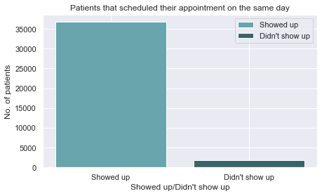

```python
# Number of patients that showed up that scheduled on the same day of the appointment
show = df[df['Days']==0]['No-show'].value_counts()[0]
# Number of patients that did not show up that scheduled on the same day of the appointment
noshow = df[df['Days']==0]['No-show'].value_counts()[1]

bargraph('Showed up', 'Didn\'t show up', show, noshow, color1='#68a5ac', color2='#396469',
         title='Patients that scheduled their appointment on the same day',
         xlabel='Showed up/Didn\'t show up', ylabel='No. of patients')
```

> We can see that patients that schedule their appointment to be on the **same day** that they called to schedule almost always **show up**.

**Number of days between scheduling and appointment**

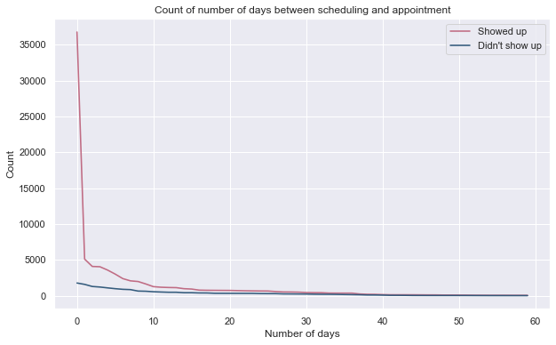

```python
sns.set()
fig = plt.figure(figsize =(10, 6))
plt.plot(show_df['Days'].value_counts()[0:60].values, label='Showed up', color = '#C06C84', linewidth=1.6)
plt.plot(noshow_df['Days'].value_counts()[0:60].values, label='Didn\'t show up', color = '#355C7D', linewidth=1.6)
plt.ylabel('Count')
plt.xlabel('Number of days')
plt.title('Count of number of days between scheduling and appointment')
plt.legend()
plt.show()
```

> If the patient scheduled **10 days or less** before the appointment, they are most likely to **show up**.

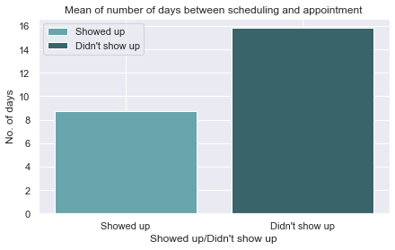

```python
# Mean of number of days between scheduling and appointment
show_mean = show_df['Days'].mean()
noshow_mean = noshow_df['Days'].mean()

bargraph('Showed up', 'Didn\'t show up', show_mean, noshow_mean, color1='#68a5ac', color2='#396469',
         title='Mean of number of days between scheduling and appointment',
         xlabel='Showed up/Didn\'t show up', ylabel='No. of days')
```

> We can see that the average count of number of days between scheduling and appointment is **higher** for patients that did **not show up**.

### Research Question 2: Which features *(Gender, Diabetes, Alcoholism, Handcap, Hypertension, Scholarship)* are related to whether the patient will show up or not?:

- Gender
- Diabetes
- Alcoholism
- Handcap
- Hypertension
- Scholarship

#### 1. Which gender is more likely to not show up?

```python
# Number of males and females that did not show up
female = noshow_df['Gender'].value_counts()[0]
male = noshow_df['Gender'].value_counts()[1]
```

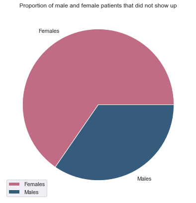

```python
sns.set()
fig = plt.figure(figsize =(10, 7))
plt.pie([female, male], labels = ['Females','Males'], colors=['#C06C84','#355C7D'])
plt.legend()
plt.title("Proportion of male and female patients that did not show up")
plt.show()
```

> It is clear that the number of patients that did not show up are mostly females, but could this be because there are more females in the dataset?

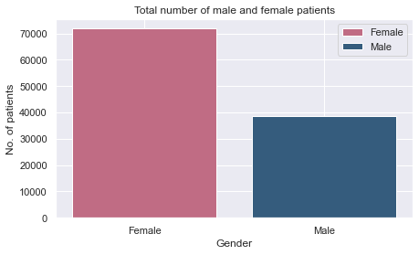

```python
# Plot the total number of males and females
total_m = df['Gender'].value_counts()[1]
total_f = df['Gender'].value_counts()[0]

bargraph('Female', 'Male', total_f, total_m, color1='#C06C84', color2='#355C7D',
         title='Total number of male and female patients',
         xlabel='Gender', ylabel='No. of patients')
```

> The number of females in the dataset is almost two times more than males, which means **female patients are more likely to make an appointment.**  
> However, the gender needs to be ratioed in order to make a fair comparison to find out which one is more likely to not show up.

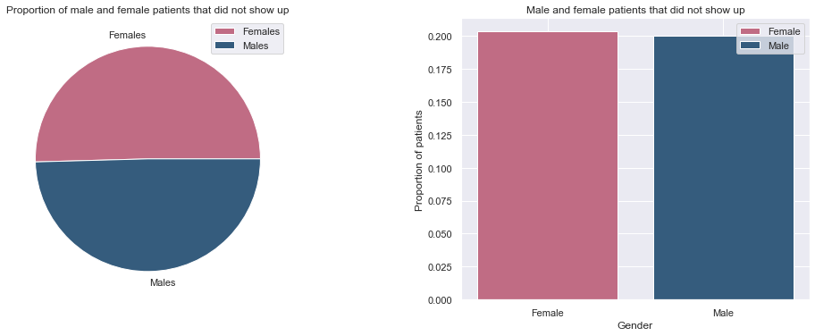

```python
# Ratio of males and females that didn't show
# eg. no. of females that didn't show / total no. of females
female_ratio = female/total_f
male_ratio = male/total_m

# Plot the graphs
sns.set()
plt.figure(figsize=(13,5))
plt.subplot(121)
pie = plt.pie([female_ratio*100, male_ratio*100], labels = ['Females','Males'], colors=['#C06C84','#355C7D'])
plt.legend()
plt.title("Proportion of male and female patients that did not show up")

# create second subplot on the right (1 row, 2 columns, position 2)
sns.set()
plt.subplot(122)
bar1 = plt.bar('Female', female_ratio, color='#C06C84', label='Female')
bar2 = plt.bar('Male', male_ratio, color='#355C7D', label='Male')
plt.title("Male and female patients that did not show up")
plt.xlabel("Gender")
plt.ylabel("Proportion of patients")
plt.legend()

plt.subplots_adjust(left=0.001,
                    right=1,
                    top=1,
                    wspace=0.4,
                    hspace=0.4)
plt.show()
```

> Wow the first graph before the ratio was definitely deceiving!  
> We can now see that the number of male and female patients that did not show up are pretty much the same.  
> Therefore, **gender is not one of the factors which determine if the patient will show up or not.**

Used this for help to put the graphs side by side: https://stackoverflow.com/questions/56298327/how-to-scale-a-pie-chart-and-bar-chart-to-both-display

#### 2. Are patients with diabetes more likely to show up or not?

```python
# Count the total number of patients with diabetes
total_diabetes = df['Diabetes'].value_counts()[1]

# Proportions of people with diabetes that showed up and didn't show up
show_diabetes = show_df['Diabetes'].value_counts()[1]/total_diabetes
noshow_diabetes = noshow_df['Diabetes'].value_counts()[1]/total_diabetes
```

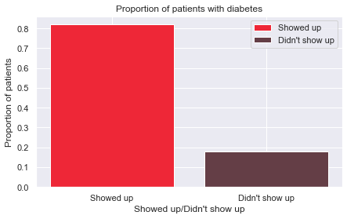

```python
bargraph('Showed up', 'Didn\'t show up', show_diabetes, noshow_diabetes,'#EE2737FF', '#643E46FF',
         title='Proportion of patients with diabetes',
         xlabel='Showed up/Didn\'t show up', ylabel='Proportion of patients')
```

> 80% of people with diabetes show up to the appointments, while 20% of them don't.  
> People with **diabetes** are more likely to **show up** to the appointments.

#### 3. Are alcoholic patients more likely to show up or not?

```python
# Number of alcoholic patients that showed up and did not show up
show_alc = show_df['Alcoholism'].value_counts()[1]
noshow_alc = noshow_df['Alcoholism'].value_counts()[1]
```

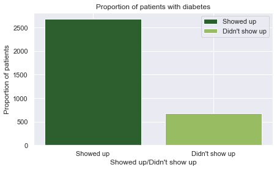

```python
bargraph('Showed up', 'Didn\'t show up', show_alc, noshow_alc,'#2C5F2D','#97BC62FF',
         title='Proportion of patients with diabetes',
         xlabel='Showed up/Didn\'t show up', ylabel='Proportion of patients')
```

> We can see that **alcoholic** patients are more likely to **show up.**

#### 4. Are handicapped patients more likely to show up or not?

```python
# Number of handicapped patients that showed up and did not show up
show_handcap = show_df['Handcap'].value_counts()[1]
noshow_handcap = noshow_df['Handcap'].value_counts()[1]
```

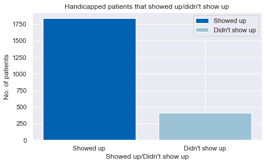

```python
bargraph('Showed up', 'Didn\'t show up', show_handcap, noshow_handcap,'#0063B2FF','#9CC3D5FF',
         title='Handicapped patients that showed up/didn\'t show up',
         xlabel='Showed up/Didn\'t show up', ylabel='No. of patients')
```

> We can see that **handicapped** patients are also more likely to **show up.**

#### 5. Are patients with hypertension more likely to show up or not?

```python
# Number of patients that have hypertension that showed up and did not show up
show_hyp = show_df['Hipertension'].value_counts()[1]
noshow_hyp = noshow_df['Hipertension'].value_counts()[1]
```

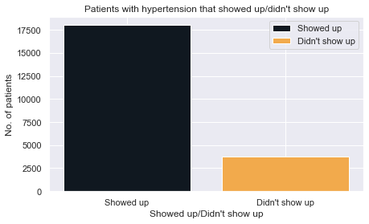

```python
bargraph('Showed up', 'Didn\'t show up', show_hyp, noshow_hyp,'#101820FF','#F2AA4CFF',
         title='Patients with hypertension that showed up/didn\'t show up',
         xlabel='Showed up/Didn\'t show up', ylabel='No. of patients')
```

> Patients with **hypertension** are more likely to **show up.**

#### 6. Are patients with a scholarship more likely to show up or not?

```python
# Number of patients that have a scholarship that showed up and did not show up
show_scholar = show_df['Scholarship'].value_counts()[1]
noshow_scholar = noshow_df['Scholarship'].value_counts()[1]
```

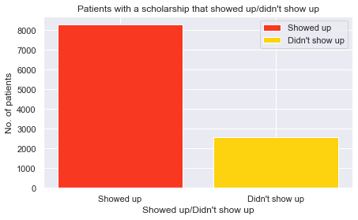

```python
bargraph('Showed up', 'Didn\'t show up', show_scholar, noshow_scholar,'#F93822FF','#FDD20EFF',
         title='Patients with a scholarship that showed up/didn\'t show up',
         xlabel='Showed up/Didn\'t show up', ylabel='No. of patients')
```

> Patients with **scholarship** are more likely to **show up** as well.

### Research Question 3: Which age groups are more likely to show up or not?

```python
df['Age'].describe()
```

```
count    110521.000000
mean         37.089386
std          23.109885
min           0.000000
25%          18.000000
50%          37.000000
75%          55.000000
max         115.000000
Name: Age, dtype: float64
```

> The ages range from 0 to 115  
> They will be divided into 5 groups:  
> **1.** 0-5  
> **2.** 6-17  
> **3.** 18-34  
> **4.** 35-64  
> **5.** 65+

```python
# Count the total number of patients in each age group
g1 = len(df.query('Age <= 5'))
g2 = len(df.query('6<= Age <= 17'))
g3 = len(df.query('18<= Age <= 34'))
g4 = len(df.query('35<= Age <= 64'))
g5 = len(df.query('Age >= 65'))
```

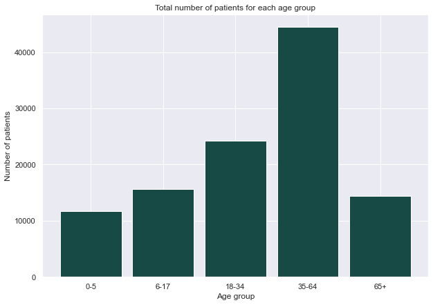

```python
total_groups = [g1, g2, g3, g4, g5]
labels = ['0-5', '6-17', '18-34', '35-64', '65+']

sns.set()
width = 0.85
plt.figure(figsize=(10,7))
plt.bar(labels, total_groups, width, color='#184A45FF')
plt.title('Total number of patients for each age group')
plt.xlabel('Age group')
plt.ylabel('Number of patients')
plt.xticks(labels)
plt.show()
```

> We can see a huge portion of the patients are aged between **35 and 64.**  
> However, just like gender, we need to fairly determine whether each age group will show up or not.  
> Therefore, I will get the proportions.

```python
# Count the number of patients that showed up in each group, and get the proportion
g1_show = len(show_df.query('Age <= 5'))/g1
g2_show = len(show_df.query('6<= Age <= 17'))/g2
g3_show = len(show_df.query('18<= Age <= 34'))/g3
g4_show = len(show_df.query('35<= Age <= 64'))/g4
g5_show = len(show_df.query('Age >= 65'))/g5
```

```python
# Count the number of patients that did not show up in each group, and get the proportion
g1_noshow = len(noshow_df.query('Age <= 5'))/g1
g2_noshow = len(noshow_df.query('6<= Age <= 17'))/g2
g3_noshow = len(noshow_df.query('18<= Age <= 34'))/g3
g4_noshow = len(noshow_df.query('35<= Age <= 64'))/g4
g5_noshow = len(noshow_df.query('Age >= 65'))/g5
```

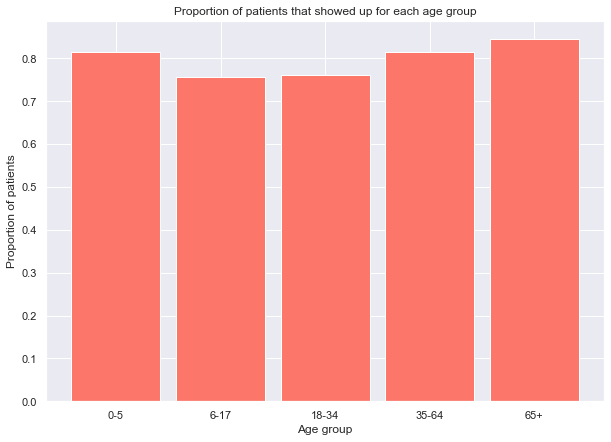

```python
# Graph the number of patients in each group that showed up to appointments
showed_groups = [g1_show, g2_show, g3_show, g4_show, g5_show]
labels_s = ['0-5', '6-17', '18-34', '35-64', '65+']

sns.set()
width = 0.85
plt.figure(figsize=(10,7))
plt.bar(labels_s, showed_groups, width, color='#FC766AFF')
plt.title('Proportion of patients that showed up for each age group')
plt.xlabel('Age group')
plt.ylabel('Proportion of patients')
plt.xticks(labels_s)
plt.show()
```

> People aged **65+** show up to the appointments the **most.**  
> People aged **6-17** show up to the appointments the **least.**

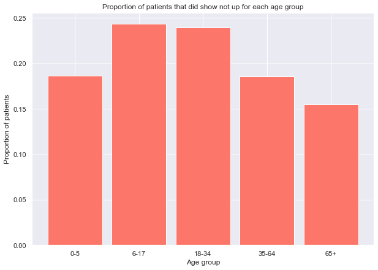

```python
# Graph the number of patients in each group that did not show up to appointments
noshowed_groups = [g1_noshow, g2_noshow, g3_noshow, g4_noshow, g5_noshow]
labels = ['0-5', '6-17', '18-34', '35-64', '65+']

sns.set()
width = 0.85
plt.figure(figsize=(10,7))
plt.bar(labels, noshowed_groups, width, color='#FC766AFF')
plt.title('Proportion of patients that did show not up for each age group')
plt.xlabel('Age group')
plt.ylabel('Proportion of patients')
plt.xticks(labels)
plt.show()
```

> This graph shows us the difference more clearly.

> People aged **65+** show up to the appointments the **most.**  
> People aged **6-17** show up to the appointments the **least.**

> Ranking the age groups, from **most likely to least likely** to **show up** to appointments:
> - 65+
> - 0-5 and 35-64 are almost the same
> - 18-34
> - 6-17

### Research Question 4: Which appointment day of the week are patients more likely to show up or not?

```python
# Number of patients that have an appointment for each of the week
week_days = [len(df[df['ScheduledDayOfWeek']=='Monday']),len(df[df['ScheduledDayOfWeek']=='Tuesday']),len(df[df['ScheduledDayOfWeek']=='Wednesday']),len(df[df['ScheduledDayOfWeek']=='Thursday']),len(df[df['ScheduledDayOfWeek']=='Friday']),len(df[df['ScheduledDayOfWeek']=='Saturday'])]

labels = ["Monday",'Tuesday','Wednesday','Thursday','Friday','Saturday']
```

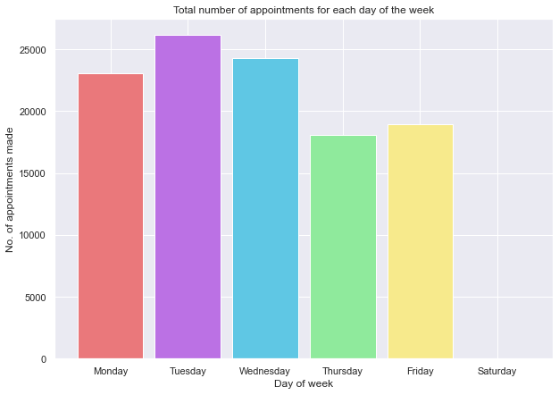

```python
# Graph the total number of patients for each day of the week
sns.set()
width = 0.85
plt.figure(figsize=(10,7))
plt.bar(labels, week_days, width, color=['#EA787B', '#BB71E4','#5FC7E4','#8FEA9C','#F7EA8C','#F4B58E'])
plt.title('Total number of appointments for each day of the week')
plt.xlabel('Day of week')
plt.ylabel('No. of appointments made')
plt.xticks(labels)
plt.show()
```

```python
# Number of patients that have an appointment for each day of the week, divided into two lists (showed up and didn't show up)
show_days = [len(show_df[show_df['ScheduledDayOfWeek']=='Monday']),len(show_df[show_df['ScheduledDayOfWeek']=='Tuesday']),len(show_df[show_df['ScheduledDayOfWeek']=='Wednesday']),len(show_df[show_df['ScheduledDayOfWeek']=='Thursday']),len(show_df[show_df['ScheduledDayOfWeek']=='Friday']),len(show_df[show_df['ScheduledDayOfWeek']=='Saturday'])]
noshow_days = [len(noshow_df[noshow_df['ScheduledDayOfWeek']=='Monday']),len(noshow_df[noshow_df['ScheduledDayOfWeek']=='Tuesday']),len(noshow_df[noshow_df['ScheduledDayOfWeek']=='Wednesday']),len(noshow_df[noshow_df['ScheduledDayOfWeek']=='Thursday']),len(noshow_df[noshow_df['ScheduledDayOfWeek']=='Friday']),len(noshow_df[noshow_df['ScheduledDayOfWeek']=='Saturday'])]
```

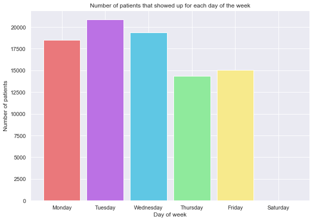

```python
# Graph the number of patients that showed up for each day of the week
sns.set()
width = 0.85
plt.figure(figsize=(10,7))
plt.bar(labels, show_days, width, color=['#EA787B', '#BB71E4','#5FC7E4','#8FEA9C','#F7EA8C','#F4B58E'])
plt.title('Number of patients that showed up for each day of the week')
plt.xlabel('Day of week')
plt.ylabel('Number of patients')
plt.xticks(labels)
plt.show()
```

> Many patients that book an appointment for **Tuesday** show up on that day.  
> Patients that book an appointment for **Thursday** tend to show up the least.

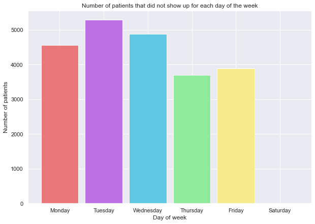

```python
# Graph the number of patients that did not show up for each day of the week
sns.set()
width = 0.85
plt.figure(figsize=(10,7))
plt.bar(labels, noshow_days, width, color=['#EA787B', '#BB71E4','#5FC7E4','#8FEA9C','#F7EA8C','#F4B58E'])
plt.title('Number of patients that did not show up for each day of the week')
plt.xlabel('Day of week')
plt.ylabel('Number of patients')
plt.xticks(labels)
plt.show()
```

> This graph is almost the same as the one above, which contradicts the conclusion that I made above.  
> One of the possibilities is because there are no proportions.

```python
# Propotion of patients that have an appointment for each day of the week, divided into two lists (showed up and didn't show up)
show_days = [len(show_df[show_df['ScheduledDayOfWeek']=='Monday'])/week_days[0], len(show_df[show_df['ScheduledDayOfWeek']=='Tuesday'])/week_days[1] ,len(show_df[show_df['ScheduledDayOfWeek']=='Wednesday'])/week_days[2],len(show_df[show_df['ScheduledDayOfWeek']=='Thursday'])/week_days[3],len(show_df[show_df['ScheduledDayOfWeek']=='Friday'])/week_days[4],len(show_df[show_df['ScheduledDayOfWeek']=='Saturday'])/week_days[5]]

noshow_days = [len(noshow_df[noshow_df['ScheduledDayOfWeek']=='Monday'])/week_days[0], len(noshow_df[noshow_df['ScheduledDayOfWeek']=='Tuesday'])/week_days[1] ,len(noshow_df[noshow_df['ScheduledDayOfWeek']=='Wednesday'])/week_days[2],len(noshow_df[noshow_df['ScheduledDayOfWeek']=='Thursday'])/week_days[3],len(noshow_df[noshow_df['ScheduledDayOfWeek']=='Friday'])/week_days[4],len(noshow_df[noshow_df['ScheduledDayOfWeek']=='Saturday'])/week_days[5]]
```

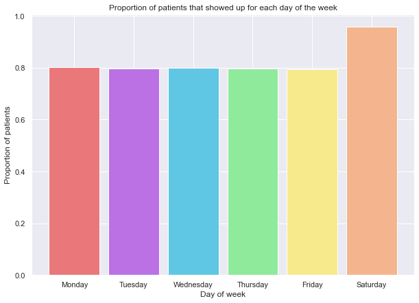

```python
# Graph the proportion of patients that showed up for each day of the week
sns.set()
width = 0.85
plt.figure(figsize=(10,7))
plt.bar(labels, show_days, width, color=['#EA787B', '#BB71E4','#5FC7E4','#8FEA9C','#F7EA8C','#F4B58E'])
plt.title('Proportion of patients that showed up for each day of the week')
plt.xlabel('Day of week')
plt.ylabel('Proportion of patients')
plt.xticks(labels)
plt.show()
```

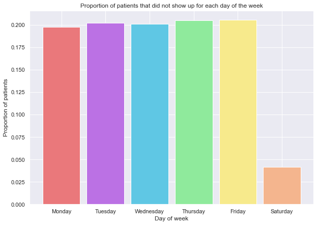

```python
# Graph the proportion of patients that did not show up for each day of the week
sns.set()
width = 0.85
plt.figure(figsize=(10,7))
plt.bar(labels, noshow_days, width, color=['#EA787B', '#BB71E4','#5FC7E4','#8FEA9C','#F7EA8C','#F4B58E'])
plt.title('Proportion of patients that did not show up for each day of the week')
plt.xlabel('Day of week')
plt.ylabel('Proportion of patients')
plt.xticks(labels)
plt.show()
```

### Research Question 5: Are patients that received an SMS more likely to show up?

#### How many patients received an SMS?

```python
received = df['SMS_received'].value_counts()[1]
not_received = df['SMS_received'].value_counts()[0]
```

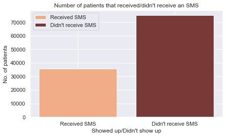

```python
bargraph('Received SMS', 'Didn\'t receive SMS', received, not_received,'#F1AC88FF','#783937FF',
         title='Number of patients that received/didn\'t receive an SMS',
         xlabel='Showed up/Didn\'t show up', ylabel='No. of patients')
```

> Most of the patients did **not** receive an SMS.

```python
# Patients that received an SMS and showed up
show_received = show_df['SMS_received'].value_counts()[1]
# Patients that received an SMS but did not show up
noshow_received = noshow_df['SMS_received'].value_counts()[1]
```

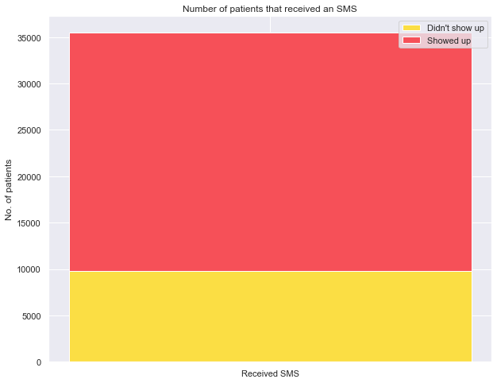

```python
labels = ['Received SMS']
showed = show_received
notshowed = noshow_received
width = 0.1

sns.set()
fig, ax = plt.subplots()
fig.set_size_inches(10, 8)
ax.bar(labels, notshowed, width, label='Didn\'t show up', color='#FBDE44FF')
ax.bar(labels, showed, width, bottom=notshowed, label='Showed up', color='#F65058FF')

ax.set_ylabel('No. of patients')
ax.set_title('Number of patients that received an SMS')
ax.legend()

plt.show()
```

### Limitations

- There was no time given for the appointment day, which could have been a great factor to determining whether a patient will show up or not.
- There were some records where the date of the appointment was before the schedule date.